# Creative Writing Analysis Through Examination of the SCP Foundation

108 Final Project by Patrick DeKelly

### Introduction

With creative AI models being in the zeitgeist now, there is a discussion about where creativity and inspiration come from. AI models are attempting, and somewhat successfully, to break down the creative process and emulate it. However, humans can arguably be said to approach creativity the same way. Humans break down sources of inspiration in our head and use those components to create something new. This begs the question: how much is a particular brush stroke or line of writing inspired by an individual piece of art we’ve seen in the past? While it would likely be impossible to ever know this to that point of precision perhaps we can still get some broader insights as to where creative inspiration comes from.

This project aims to analyze short story writing to find trends, similarities, and potential sources of inspiration. By breaking down human made writing using machine learning techniques, perhaps we can gain some insight into the creative process.

### Description of the SCP foundation and motivation for its use

The SCP foundation (Website: https://scp-wiki.wikidot.com/) is a wikipedia style database of “short stories” written in the SCP universe. This follows a fictitious secret organization that creates Special Containment Procedures (SCP) in an attempt to contain various anomalous entities and objects. They follow the format of faux classified documents describing the Special Containment Procedures (SCP) for these entities and objects. Broadly similar in concept to something like the X-files. While many articles are written in a scifi/horror genre, they are quite varied. Many are also humorous, fantastical, or existential.

While it does sound like an unusual dataset to perform writing analysis on, there are several aspects of it to make for a potentially unique opportunity:

- The SCP universe is a completely crowdsourced collaborative independent universe with countless contributors. No one person created this and, by its very design, is not controlled by one single entity. For contrast, Marvel comics also has an extensive fictional universe with many writers but their content is all controlled by marvel.
- It is very insular and writers are encouraged to build upon each other's work. In contrast, there may be lots of amateur fan fiction writers out there but they are all referencing outside works. The SCP articles largely just reference themselves and, as such, they are all contained within the database.
- While there are many different writers and styles, there are standard formatting conventions that make parsing of information easier. The articles will typically start off with this standard formatting then deviate as it is used as a jumping off point to start a narrative.
- Of substantial interest is that when one SCP article includes or references another it is standard practice to refer to it by its identification code (ex. SCP-123). This makes it particularly easy to parse out this information as few other places can you expect such consistent formatting in creative writing text. This could be leveraged for social network analysis.

# Imports

```python
import numpy as np
import pandas as pd
import matplotlib.pyplot as plt
import seaborn as sns

import os
import time
import itertools
import collections

from stop_words import get_stop_words
import re
from scipy import stats
import string

from scipy.sparse.linalg import eigs
import networkx as nx
from networkx.algorithms.community.centrality import girvan_newman
from networkx.algorithms.community import modularity, greedy_modularity_communities

from PIL import Image
from wordcloud import WordCloud, ImageColorGenerator

#prepackaged Local Sensitivity Hashing
from datasketch import MinHash, MinHashLSHForest
```

# Load in Dataset

The dataset is from Kaggle and contains the vast majority of the main SCP articles scrapped from the website. (https://www.kaggle.com/datasets/czzzzzzz/scp1to7) The dataset contains the text for 6999 articles with additional columns containing additional information such as tags, ratings, and image captions. While this dataset was created, no significant analysis appears to have been done on this set already.

```python
# scp_df = pd.read_csv('/scp_data/scp6999.csv', header=0, delimiter=',', quoting=csv.QUOTE_ALL, encoding='utf-8', index_col=False, usecols=['code', 'title', 'text', 'image captions', 'rating', 'state', 'tags',  'link'])
scp_df = pd.read_csv('scp_data/scp6999.csv')

# It's more convent, in most cases, dealing with integers for code than string
scp_df["item_#"] = [int(x.split("-")[1])for x in list(scp_df["code"].values)]

display(scp_df.head())
print(scp_df.shape)
```

|  | code | title | text | image captions | rating | state | tags | link | item_# |
| --- | --- | --- | --- | --- | --- | --- | --- | --- | --- |
| 0 | SCP-001 | "Awaiting De-classification [Blocked]" | "GENERAL NOTICE 001-Alpha: In order to prevent... | NaN | NaN | blocked | _cc _licensebox hub | https://scp-wiki.wikidot.com/scp-001 | 1 |
| 1 | SCP-002 | "The "Living" Room" | "Item #: SCP-002 \n Object Class: Euclid \n Sp... | "SCP-002 in its containment area" | 1702.0 | active | _cc _licensebox alive euclid featured scp stru... | https://scp-wiki.wikidot.com/scp-002 | 2 |
| 2 | SCP-003 | "Biological Motherboard" | "Item #: SCP-003 \n Object Class: Euclid \n Sp... | "A close up of SCP-003's circuitry" | 765.0 | active | _cc _licensebox alive biological computer dire... | https://scp-wiki.wikidot.com/scp-003 | 3 |
| 3 | SCP-004 | "The 12 Rusty Keys and the Door" | "Item #: SCP-004 \n Object Class: Euclid \n Sp... | "SCP-004-1" | 1096.0 | active | _cc _licensebox euclid key mind-affecting port... | https://scp-wiki.wikidot.com/scp-004 | 4 |
| 4 | SCP-005 | "Skeleton Key" | "Item #: SCP-005 \n Object Class: Safe \n Spec... | "A close up of SCP-005" | 645.0 | active | _cc _licensebox adaptive key metallic safe scp... | https://scp-wiki.wikidot.com/scp-005 | 5 |

```
(6999, 9)
```

The main column of focus will be the text of the article itself. Other feature columns will be of interest for evaluation. However, similarity search and clustering will be fit using exclusively the text data.

### Missing Values

```python
# check for NAN values
print("Before filling in missing values")
display(scp_df.isna().sum())

# After simple examination, these values are missing only because the article did not contain it in the first place
# There was no image or tags made for the article or it has yet to be rated. A basic indicator for nan values is applicable.
scp_df["image captions"] = scp_df["image captions"].fillna('(Missing_Caption)')
scp_df["rating"] = scp_df["rating"].fillna(0)
scp_df["tags"] = scp_df["tags"].fillna('(Missing_Tags)')


# check that NAN values were filled in
print("After filling in missing values")
display(scp_df.isna().sum())

# some articles in the set have been deleted and the articles just have a boilerplate notification of deletion
# this is convenently tagged by 'deleted' in state so we will drop those from the set
scp_df = scp_df[scp_df["state"] != 'deleted']

display(scp_df.head())
print(scp_df.shape)
```

```
Before filling in missing values
```

```
code                 0
title                0
text                 0
image captions    3894
rating             388
state                0
tags               403
link                 0
item_#               0
dtype: int64
```

```
After filling in missing values
```

```
code              0
title             0
text              0
image captions    0
rating            0
state             0
tags              0
link              0
item_#            0
dtype: int64
```

|  | code | title | text | image captions | rating | state | tags | link | item_# |
| --- | --- | --- | --- | --- | --- | --- | --- | --- | --- |
| 0 | SCP-001 | "Awaiting De-classification [Blocked]" | "GENERAL NOTICE 001-Alpha: In order to prevent... | (Missing_Caption) | 0.0 | blocked | _cc _licensebox hub | https://scp-wiki.wikidot.com/scp-001 | 1 |
| 1 | SCP-002 | "The "Living" Room" | "Item #: SCP-002 \n Object Class: Euclid \n Sp... | "SCP-002 in its containment area" | 1702.0 | active | _cc _licensebox alive euclid featured scp stru... | https://scp-wiki.wikidot.com/scp-002 | 2 |
| 2 | SCP-003 | "Biological Motherboard" | "Item #: SCP-003 \n Object Class: Euclid \n Sp... | "A close up of SCP-003's circuitry" | 765.0 | active | _cc _licensebox alive biological computer dire... | https://scp-wiki.wikidot.com/scp-003 | 3 |
| 3 | SCP-004 | "The 12 Rusty Keys and the Door" | "Item #: SCP-004 \n Object Class: Euclid \n Sp... | "SCP-004-1" | 1096.0 | active | _cc _licensebox euclid key mind-affecting port... | https://scp-wiki.wikidot.com/scp-004 | 4 |
| 4 | SCP-005 | "Skeleton Key" | "Item #: SCP-005 \n Object Class: Safe \n Spec... | "A close up of SCP-005" | 645.0 | active | _cc _licensebox adaptive key metallic safe scp... | https://scp-wiki.wikidot.com/scp-005 | 5 |

```
(6618, 9)
```

### Summary Printout Function

```python
# Examine a sample entry. Selecting SCP-005 for this.
def SCP_summary_printout(item_n):
    row = scp_df[scp_df["item_#"] == item_n]
    print(f"Item Number: "+ row["code"].values[0])
    print(f"SCP title: "+ row["title"].values[0])
    print(f"SCP image caption: "+ row["image captions"].values[0])
    print(f"SCP tags: "+ row["tags"].values[0])
    print(f"SCP rating: "+ str(row["rating"].values[0]))

    print(f"SCP text: \n\n"+ row["text"].values[0])

SCP_summary_printout(5)
```

```
Item Number: SCP-005
SCP title: "Skeleton Key"
SCP image caption: "A close up of SCP-005"
SCP tags: _cc _licensebox adaptive key metallic safe scp sentient
SCP rating: 645.0
SCP text:

"Item #: SCP-005
 Object Class: Safe
 Special Containment Procedures: SCP-005 poses no immediate risk in any direct sense. Even so, its unique functions require special measures be taken to restrict access and manipulation of the object. Approval of at least one (1) Level 4 personnel is required for the removal of the object from its c…
 Description: In appearance, SCP-005 resembles an ornate key, displaying the characteristics of a typical mass produced key used in the 1920s. The key was discovered when a civilian used it to infiltrate a high security facility. SCP-005 seems to have the unique ability to open any and all forms of …
 Additional Notes: SCP-005 may be used as a replacement for lost security passes, but only under the supervision of at least one (1) Level 4 personnel. SCP-005 may not be used for vending machine repairs, opening lockers, or for any personnel's spare home key. Removal of the object from the compound…
 Appendix A: While SCP-005 has been shown to be effective in removing almost any form of locking device, further experiments have shown that efforts to disguise the purpose or identity of a lock have proven at least somewhat successful in defeating SCP-005's ability. In approximately 50% of cases wh…
 « SCP-004 | SCP-005 | SCP-006 »
 Cite this page as:
 "SCP-005" by Unknown Author, from the SCP Wiki. Source: https://scp-wiki.wikidot.com/scp-005. Licensed under CC-BY-SA.
 For more information, see Licensing Guide.
Licensing Disclosures
 Filename: SCP-005.jpg
Author: Brian Uhreen
License: Copyrighted (Used with permission)
Source Link: flickr
 For more information about on-wiki content, visit the Licensing Master List."
```

The raw text is from a web scraper. There does not seem to be too much of an attempt to parse out information and many articles contain outside text like copywrite, links, author and moderator notes. While there are many articles that follow a standard formatting for the website, there is a lot of inconsistent formatting between articles.

# Feature engineering and preprocessing of text

### Authorship

Due to inconsistent formatting of articles, it is somewhat tricky to programmatically extract the authors who wrote each article. Some are listed at the end of the page but in slightly different ways. Many are anonymous and some have no author information at all from what was gathered by the web scraper. Can only programmatically extract the authors for about 2000 articles. However, this should be enough for analysis later.

```python
# create a function to attempt to find article author's names
def find_author(x):
    try:
        y = x.split('« SCP')[1]
        start = y.index( "Author: " ) + len( "Author: " )
        end = y.index( '\nLicense:', start )
        return y[start:end]
    except:
        try:
            y = x.split('« SCP')[1]
            start = y.index( '" by ' ) + len( '" by ' )
            end = y.index( ', ', start )
            return y[start:end]
        except:
            try:
                y = x.split('Cite this page as:')[1]
                start = y.index( '" by ' ) + len( '" by ' )
                end = y.index( ', ', start )
                return y[start:end]
            except:
                return "<UNKNOWN>"
# apply function
scp_df["author"] = scp_df["text"].apply(find_author)

# check ammount found
found_authors = scp_df[scp_df["author"] != "<UNKNOWN>"].shape[0]
print(f"{found_authors} articles have found authors by the previous methods")
```

```
2151 articles have found authors by the previous methods
```

### Remove non-article text

Again the formatting of articles is not consistent. As such, many articles have text not part of the article itself. This might be acknowledgments, author pages, moderator notes, etc. These need to be removed if the goal is to analyze similarities and differences in writing style.

```python
# As can be seen, text articles still contain the end site information so stripping that out.
# 2251 and 2664 are problematic for these steps so are skipped
problem_indexes = [2251,2664]
mask_df = scp_df.loc[~scp_df['item_#'].isin(problem_indexes)]
scp_df.loc[~scp_df['item_#'].isin(problem_indexes),'text'] = mask_df['text'].apply(lambda x : x.split('« SCP')[0])
scp_df.loc[~scp_df['item_#'].isin(problem_indexes),'text'] = mask_df['text'].apply(lambda x : x.split('Cite this page as:')[0])

# After preforming Social Network Analysis the first time, I found that some authors
# listed their other articles at the end. This is noise for referencing so removing
# the non-article text from those that were found as well. may be able to find a few missing author names at the same time

mask_df = scp_df.loc[scp_df['text'].str.contains("\'s Works")]
scp_df.loc[scp_df['text'].str.contains("\'s Works"),"author"] = mask_df['text'].apply(lambda x : x.split("\'s Works")[0].split()[-1])
scp_df.loc[scp_df['text'].str.contains("\'s Works"), "text"] = mask_df['text'].apply(lambda x : x.split("\'s Works")[0])


# Calibold had authors page matterial at both the top and bottom of every article, parsing out
mask_df = scp_df.loc[scp_df['text'].str.contains("Mega Cool Author Page")]
scp_df.loc[scp_df['text'].str.contains("Mega Cool Author Page"), "author"] = "Calibold"
scp_df.loc[scp_df['text'].str.contains("Mega Cool Author Page"), "text"] = mask_df["text"].apply(lambda x : x.split("Mega Cool Author Page")[1])

# some articles had notes from a moderator about CSS improvements and whatnot
# the notes varied but all seemed to end with "…like this!" so split that section out
mask_df = scp_df.loc[scp_df['text'].str.contains("…like this!")]
scp_df.loc[scp_df['text'].str.contains("…like this!"), "text"] = mask_df["text"].apply(lambda x : x.split("…like this!")[1])

# some articles contain a preamble by the author with acknowlegments, etc.
# Not consistant enough to automatically parse features but should be removed from main article text
mask_df = scp_df.loc[scp_df['text'].str.contains("▸ More by this Author ◂")]
scp_df.loc[scp_df['text'].str.contains("▸ More by this Author ◂"), "text"] = mask_df['text'].apply(lambda x : x.split("▸ More by this Author ◂")[1])

found_authors = scp_df[scp_df["author"] != "<UNKNOWN>"].shape[0]

print(f"{found_authors} articles have found authors by the previous methods")

# some articles have duplicate text. This is due to error messages or similar issues
# can remove them now since we parsed out endsite information
scp_df.drop_duplicates(subset=['text'], keep=False, inplace=True)
```

```
2221 articles have found authors by the previous methods
```

### Length of text features

```python
# Length of articles by characters and by words
text = [str(i)[1:-1].split() for i in scp_df['text']]
scp_df["char length"] = [len(i) for i in scp_df['text']]
scp_df["words length"] = [len(i) for i in text]

scp_df.head()
```

|  | code | title | text | image captions | rating | state | tags | link | item_# | author | char length | words length |
| --- | --- | --- | --- | --- | --- | --- | --- | --- | --- | --- | --- | --- |
| 0 | SCP-001 | "Awaiting De-classification [Blocked]" | "GENERAL NOTICE 001-Alpha: In order to prevent... | (Missing_Caption) | 0.0 | blocked | _cc _licensebox hub | https://scp-wiki.wikidot.com/scp-001 | 1 | Staff | 2616 | 408 |
| 1 | SCP-002 | "The "Living" Room" | "Item #: SCP-002 \n Object Class: Euclid \n Sp... | "SCP-002 in its containment area" | 1702.0 | active | _cc _licensebox alive euclid featured scp stru... | https://scp-wiki.wikidot.com/scp-002 | 2 | Unknown Author | 4934 | 777 |
| 2 | SCP-003 | "Biological Motherboard" | "Item #: SCP-003 \n Object Class: Euclid \n Sp... | "A close up of SCP-003's circuitry" | 765.0 | active | _cc _licensebox alive biological computer dire... | https://scp-wiki.wikidot.com/scp-003 | 3 | ZeptoBars | 11313 | 1711 |
| 3 | SCP-004 | "The 12 Rusty Keys and the Door" | "Item #: SCP-004 \n Object Class: Euclid \n Sp... | "SCP-004-1" | 1096.0 | active | _cc _licensebox euclid key mind-affecting port... | https://scp-wiki.wikidot.com/scp-004 | 4 | Anonymous | 8952 | 1378 |
| 4 | SCP-005 | "Skeleton Key" | "Item #: SCP-005 \n Object Class: Safe \n Spec... | "A close up of SCP-005" | 645.0 | active | _cc _licensebox adaptive key metallic safe scp... | https://scp-wiki.wikidot.com/scp-005 | 5 | Brian Uhreen | 1933 | 315 |

Some articles have little/no text, or at least no meaningful text was scraped. This can be due to the web scraper not collecting the entire article or due to an unusual non-text based format. SCP-2521, for example, is somewhat creatively told only using pictograms with the excuse being that writing or talking about the SCP is deadly. Either way, cannot easily incorporate these blank text articles so will also need to be deleted.

```python
scp_df = scp_df[scp_df["char length"]>= 200]
scp_df = scp_df[scp_df["words length"] >= 50]
```

### Applying standard text preprocessing to start

```python
%%time
# Applying standard text preprocessing to start

# stop words
stop_words = get_stop_words('en')

# converting all text to lower case in the Phrase column
scp_df['text_processed'] = scp_df['text'].apply(str.lower)

# using regex to remove punctuation
scp_df['text_processed'] = scp_df['text_processed'].apply(lambda x: re.sub(r'[^\w\s]', '', x)
                                      )

# removing stop words
scp_df['text_processed'] = scp_df['text_processed'].apply(lambda x: ' '.join(
    w for w in x.split() if w not in stop_words))


scp_df['text_processed']
```

```
CPU times: total: 16.7 s
Wall time: 35.5 s
```

```
0       general notice 001alpha order prevent knowledg...
1       item scp002 object class euclid special contai...
2       item scp003 object class euclid special contai...
3       item scp004 object class euclid special contai...
4       item scp005 object class safe special containm...
                              ...
6994    item scp6995 object class euclid special conta...
6995    faq special containment procedures objects scp...
6996    item scp6997 object class safe special contain...
6997    item scp6998 object class na special containme...
6998    faq o510 personnel listserv figured may curiou...
Name: text_processed, Length: 6593, dtype: object
```

### Other SCP Referenced in Articles

Of interest to me is that when one SCP article includes or references another, it is standard practice to refer to it by its identification code (ex. SCP-123). This makes it particularly easy to parse out this information as few other places can you expect such consistent formatting in creative writing text. I believe this could be leveraged to attempt social network analysis on the texts later.

```python
# finding other SCPs referenced in articles
def extract_SCP_references(x):
    text = str(x)[1:-1].split()

# set up to remove punctation but *not* hyphens as they are important
remove = string.punctuation
remove = remove.replace("-", "") # don't remove hyphens
pattern = r"[{}]".format(remove) # create the pattern

text = [str(i)[1:-1].split() for i in scp_df['text']]
code_arr = scp_df['code'].values
ref_scp = []
for i,t in enumerate(text):
    l = set()
    for x in t:
        if x.startswith("SCP-") and x.startswith(code_arr[i]) == False:
            # remove non hyphen punctuation at this point
            n = re.sub(pattern, "", x)
            # split on hyphen and take the second
            n = n.split("-")[1]
            # removing non-numbers.
            n = ''.join(ch for ch in n if ch.isdigit())
            try:
                l.add(int(n))
            except:
                # if the previous steps don't result in a number the SCP string was either censored or not actually an object
                # pass in this case
                pass
    ref_scp.append(list(l))

# ref_scp = [set(ref_scp)]
# ref_scp = list(ref_scp)
# place in dataframe
scp_df["SCPs referenced"] = ref_scp
# and the count of references
scp_df["SCPs referenced length"] = [len(i) for i in ref_scp]
reference_length = scp_df.loc[scp_df["SCPs referenced length"] > 0].shape[0]
print(f"There are {reference_length} articles that reference at least 1 other SCP")
scp_df.head()
```

```
There are 6342 articles that reference at least 1 other SCP
```

|  | code | title | text | image captions | rating | state | tags | link | item_# | author | char length | words length | text_processed | SCPs referenced | SCPs referenced length |
| --- | --- | --- | --- | --- | --- | --- | --- | --- | --- | --- | --- | --- | --- | --- | --- |
| 0 | SCP-001 | "Awaiting De-classification [Blocked]" | "GENERAL NOTICE 001-Alpha: In order to prevent... | (Missing_Caption) | 0.0 | blocked | _cc _licensebox hub | https://scp-wiki.wikidot.com/scp-001 | 1 | Staff | 2616 | 408 | general notice 001alpha order prevent knowledg... | [] | 0 |
| 1 | SCP-002 | "The "Living" Room" | "Item #: SCP-002 \n Object Class: Euclid \n Sp... | "SCP-002 in its containment area" | 1702.0 | active | _cc _licensebox alive euclid featured scp stru... | https://scp-wiki.wikidot.com/scp-002 | 2 | Unknown Author | 4934 | 777 | item scp002 object class euclid special contai... | [1, 3] | 2 |
| 2 | SCP-003 | "Biological Motherboard" | "Item #: SCP-003 \n Object Class: Euclid \n Sp... | "A close up of SCP-003's circuitry" | 765.0 | active | _cc _licensebox alive biological computer dire... | https://scp-wiki.wikidot.com/scp-003 | 3 | ZeptoBars | 11313 | 1711 | item scp003 object class euclid special contai... | [1512, 2, 2756, 4] | 4 |
| 3 | SCP-004 | "The 12 Rusty Keys and the Door" | "Item #: SCP-004 \n Object Class: Euclid \n Sp... | "SCP-004-1" | 1096.0 | active | _cc _licensebox euclid key mind-affecting port... | https://scp-wiki.wikidot.com/scp-004 | 4 | Anonymous | 8952 | 1378 | item scp004 object class euclid special contai... | [3, 5] | 2 |
| 4 | SCP-005 | "Skeleton Key" | "Item #: SCP-005 \n Object Class: Safe \n Spec... | "A close up of SCP-005" | 645.0 | active | _cc _licensebox adaptive key metallic safe scp... | https://scp-wiki.wikidot.com/scp-005 | 5 | Brian Uhreen | 1933 | 315 | item scp005 object class safe special containm... | [4, 6] | 2 |

### Seprating the tags column

```python
# get dummy columns and create a seperate tags df
tags_df = scp_df["tags"].str.get_dummies(' ')

print(f"there are {tags_df.shape[1]} unique tags in the dataset")

# Concat to the main df
scp_df = pd.concat(
    [
        scp_df,
        tags_df,
    ],
    axis=1,
)
```

```
there are 523 unique tags in the dataset
```

# EDA

### SCP Reference Length

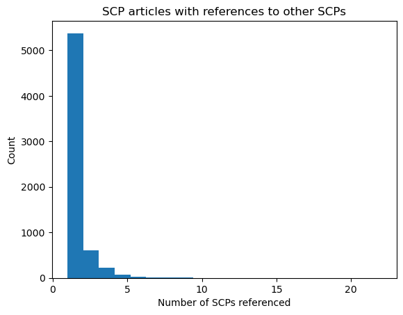

```python
num_ref = scp_df.loc[scp_df["SCPs referenced length"] > 0]["SCPs referenced length"].values

plt.hist(num_ref, bins=20, density=False, alpha=1)
plt.title("SCP articles with references to other SCPs")
plt.ylabel('Count')
plt.xlabel('Number of SCPs referenced')
plt.xticks(range(0,21,5))

plt.show()
```

### Article Length

```
count     6593.000000
mean      1556.594115
std       1607.414090
min         56.000000
25%        672.000000
50%       1093.000000
75%       1866.000000
max      35147.000000
Name: words length, dtype: float64
```

```
**Longest article by word count**
```

|  | code | title | text | image captions | rating | state | tags | link | item_# | author | ... | wandsmen | war-on-all-fronts | weapon | westhead-media | wilsons-wildlife | wonderful-world | wooden | xenarthran | xia-dynasty | zyn-kiryu |
| --- | --- | --- | --- | --- | --- | --- | --- | --- | --- | --- | --- | --- | --- | --- | --- | --- | --- | --- | --- | --- | --- |
| 6089 | SCP-6090 | "Therianthropy Virus" | \n F.A.Q. \n ChaosMageX\nClick the Info Bar i... | "Full Moonlight is a cognitohazard for both SC... | 60.0 | age restricted | weapon amorphous biological metamorphic redire... | https://scp-wiki.wikidot.com/adult:scp-6090/no... | 6090 | ChaosMageX | ... | 0 | 0 | 1 | 0 | 1 | 0 | 0 | 0 | 0 | 0 |

1 rows × 538 columns

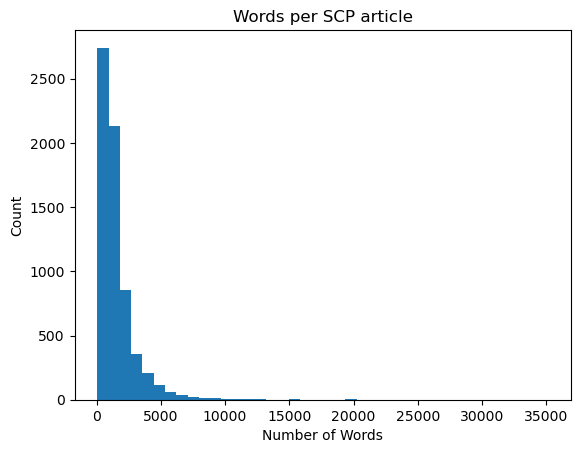

```python
num_words = scp_df["words length"].values

plt.hist(num_words, bins=40, density=False, alpha=1)
plt.title("Words per SCP article")
plt.ylabel('Count')
plt.xlabel('Number of Words')
# plt.xticks(range(0,21,5))
display(scp_df["words length"].describe())
print("**Longest article by word count**")
display(scp_df.loc[scp_df["words length"] == num_words.max()])
plt.show()
```

### Rating

```
count    6593.000000
mean      169.934173
std       249.234837
min       -36.000000
25%        56.000000
50%       107.000000
75%       200.000000
max      7663.000000
Name: rating, dtype: float64
```

```
**Highest rated article**
```

|  | code | title | text | image captions | rating | state | tags | link | item_# | author | ... | wandsmen | war-on-all-fronts | weapon | westhead-media | wilsons-wildlife | wonderful-world | wooden | xenarthran | xia-dynasty | zyn-kiryu |
| --- | --- | --- | --- | --- | --- | --- | --- | --- | --- | --- | --- | --- | --- | --- | --- | --- | --- | --- | --- | --- | --- |
| 172 | SCP-173 | "The Original" | "Item #: SCP-173 \n Object Class: Euclid \n Sp... | (Missing_Caption) | 7663.0 | active | _licensebox autonomous euclid featured hostile... | https://scp-wiki.wikidot.com/scp-173 | 173 | Moto42 | ... | 0 | 0 | 0 | 0 | 0 | 0 | 0 | 0 | 0 | 0 |

1 rows × 538 columns

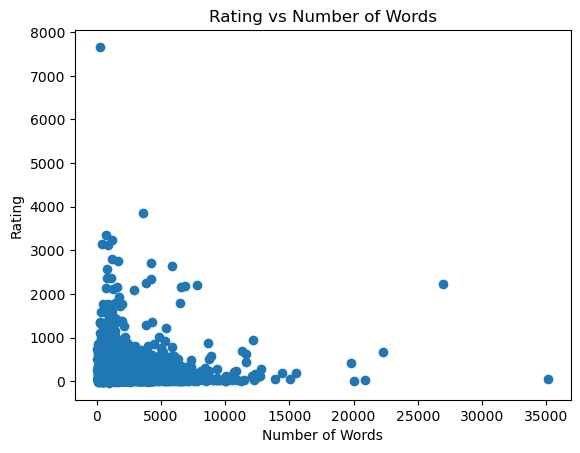

```python
plt.scatter(scp_df["words length"],scp_df["rating"])
plt.title("Rating vs Number of Words")
plt.ylabel('Rating')
plt.xlabel('Number of Words')
display(scp_df["rating"].describe())
print("**Highest rated article**")
display(scp_df.loc[scp_df["rating"] == scp_df["rating"].max()])
plt.show()
```

It appears that more of the most popular articles are of a lower word count. However, the scatter plot while useful at detecting outliers the vast majority of observations have less than a few hundred ratings. Here we can also tell the difference in word counts for the most extreme cases. There are only a few that are over 15,000 so SCP-6090 is an extreme outlier. The top rated article is SCP-173. This is no surprise as that is the original first SCP created and is rather famous. Despite it being an objectively fairly mediocre article with a low word count, it remains highly rated.

### Tags

```
count     523.000000
mean      115.474187
std       398.492851
min         1.000000
25%         6.000000
50%        22.000000
75%        93.500000
max      6547.000000
dtype: float64
```

```
**Top 20 most common tags**
```

```
scp                 6547
_cc                 3232
euclid              2521
safe                2171
_licensebox         1956
sentient            1931
humanoid            1689
sapient             1562
alive               1313
keter               1148
mind-affecting       988
animal               709
visual               684
cognitohazard        629
extradimensional     626
ectoentropic         609
location             519
transfiguration      515
building             510
uncontained          466
dtype: int64
```

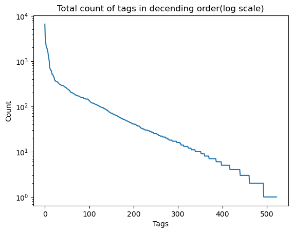

```python
num_tags = tags_df.sum().sort_values(ascending=False)

plt.plot(num_tags.values)
plt.title("Total count of tags in decending order(log scale)")
plt.ylabel('Count')
plt.xlabel('Tags')
plt.yscale('log')
display(num_tags.describe())
print("**Top 20 most common tags**")
display(num_tags[:20])
plt.show()
```

We can see that the majority of tags are rarely used. About 80% have less than 100 counts. Some of the very common ones are not that useful, like scp and standard license tags. There are quite a few common ones that could be useful for subsetting. Particular interest is the object class tags.

### Object Class

Most SCPs have an object classification. This in universe represents how difficult the object is to contain. The vast majority are classified safe, euclid, or keter but there are a few rarer classifications and the occasional article that will make up its own. They are as follows:

- Safe: SCPs that are very easy to contain or do not need many resources to contain.
- Euclid: SCPs that require more resources to contain completely or where containment isn't always reliable.
- Keter: SCPs that are very difficult to contain or haven't yet been contained.
- Thaumiel: SCPs used by personnel in containing or counteracting other SCPs.
- Neutralized: SCPs that have been destroyed or disabled by intentional or accidental means.
- Apollyon: SCP that are impossible to contain and/or are expected to breach containment very often.
- Archon: SCP's that can be contained but are not due to their positive anomalous effects on our planet's reality.

There is also an anomalous classification listed. However, it does not appear in tags and is too general a word to parse out. Recent SCP articles have attempted a newer more complex classification system. However, this data is scrapped from a few years ago and I would rightfully criticize the new system for being more complex than it needs to be.

```python
# Classification columns safe,euclid,keter,thaumiel,neutralized,apollyon,anomalous,archon
classification_cols = ["safe","euclid","keter","thaumiel","neutralized","apollyon","archon"]

num_classification = tags_df[classification_cols].sum().sort_values(ascending=False)

print(f" There are a total of {scp_df[scp_df[classification_cols].sum(axis=1) >= 1].shape[0]} articles with a classification tag")
print(f" {scp_df[scp_df[classification_cols].sum(axis=1) > 1].shape[0]} articles have more than one a classification tag")
print(f" {scp_df[scp_df[classification_cols].sum(axis=1) == 0].shape[0]} articles have no classification tag")
display(num_classification)
```

```
 There are a total of 6237 articles with a classification tag
 93 articles have more than one a classification tag
 356 articles have no classification tag
```

```
euclid         2521
safe           2171
keter          1148
neutralized     288
thaumiel        161
archon           25
apollyon         17
dtype: int64
```

As suspected, the majority of the articles use one of the main 3 object classifications. We can see that some have multi classification tags. This is usually articles that have multiple entries or made reclassification part of the story. Some have none which could be a missing tag, creating their own unique tag, or otherwise not adhering to the original object class system.

```python
# Create object class column based on results
scp_df["Object Class"] = scp_df[classification_cols].idxmax(axis=1)
scp_df.loc[scp_df[classification_cols].sum(axis=1) > 1, "Object Class"] = "multiclass"
scp_df.loc[scp_df[classification_cols].sum(axis=1) == 0, "Object Class"] = "missing"
```

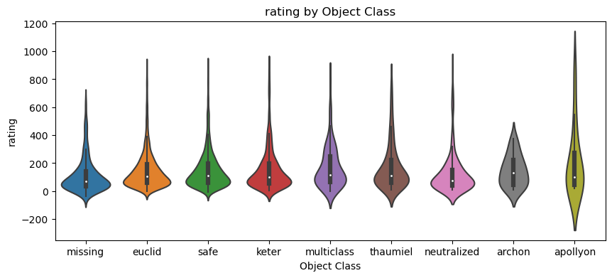

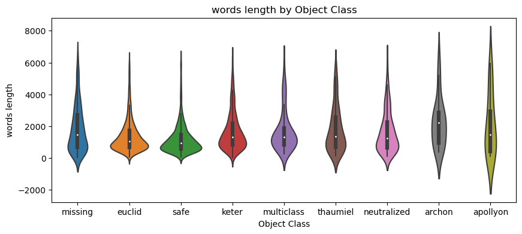

```python
# words length, rating

num_cols = ["rating","words length"]

# removing outliers for this plotting to focus on distributions
plot_df = scp_df[(np.abs(stats.zscore(scp_df["words length"])) < 3)]
plot_df = plot_df[(np.abs(stats.zscore(plot_df["rating"])) < 3)]


for i, col in enumerate(num_cols):
    plt.figure(figsize=(10,4))
    ax = sns.violinplot(x=plot_df["Object Class"],y=plot_df[col])
    ax.set_title(f"{col} by Object Class")
```

Not too much distinction in these plots. Archon articles distinctly tend to have higher ratings and longer word lengths. Though as shown before there are not that many of them. Among the major 3 (safe, euclid, and keter) their distributions seem mostly uniform on ratings. However, keter articles do tend to be longer than safe and euclid. The same holds true for any of the uncommon object classes, where the articles tend to be longer with a wider distribution. Though not a large margin safe does seem to distribute towards the lowest word counts.

### Word Cloud

Word clouds are not the most useful form of EDA in data analytics but they sure are pretty. I'll end the section with that.

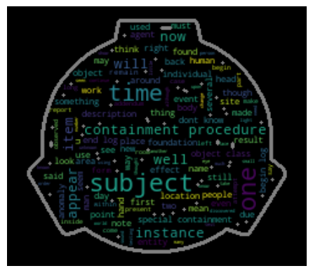

```
CPU times: total: 43.1 s
Wall time: 1min 19s
```

```python
%%time

# join all text
text = " ".join(review for review in scp_df['text_processed'])

# load in mask
scp_mask = np.array(Image.open("SCP_logo.png"))

# preform binary transformation on mask
def transform_format(val):
    if val <= 0.5:
        return 255
    else:
        return 0

transformed_scp_mask = np.ndarray((scp_mask.shape[0],scp_mask.shape[1]), np.int32)

for i in range(len(scp_mask)):
    transformed_scp_mask[i] = list(map(transform_format, scp_mask[i]))

# Create and generate a word cloud image:
wordcloud = WordCloud(mask=transformed_scp_mask,
                     contour_width=2,
#                       background_color="white",
                      contour_color='grey').generate(text)

# store to file
wordcloud.to_file("scp_cloud.png")

# Display the generated image:
plt.imshow(wordcloud, interpolation='bilinear')
plt.axis("off")
plt.show()
```

Nothing too surprising in the wordcloud. Words like subject, site, and containment procedures appear heavily. I’ll note that SCP is conspicuously absent since the processed text removed the hyphens that are usually attached. Therefore, item numbers like SCP-123 will be combined into SCP123 whereas the wordcloud on unprocessed text would separate SCP and 123.

# Similarity Search

### Local Sensitivity Hashing

The implementation of local sensitivity hashing in the homework ended up being much slower than Jaccard similarity and too slow to be of practical use on a data set this size. I modified this implementation from this tutorial to suit my needs. Jaccard similarity would take hours to complete, and LSH from the homework even slower. This takes about 5 minutes to make the LSH forest and then query all rows for all documents.

```python
%%time

# code adapted from https://www.learndatasci.com/tutorials/building-recommendation-engine-locality-sensitive-hashing-lsh-python/

# Number of Permutations
permutations = 256

#Preprocess will split a string of text into individual tokens/shingles based on whitespace.
def preprocess(text):
    tokens = set(text.split())
    return tokens


# Create Minhash Forest for Queries
def get_forest(data, perms):

    minhash = []
    # since minihash index != item number after deleting entries, create array of item number values in order
    item_nums = data["item_#"].values

    for text in data['text_processed']:
        tokens = preprocess(text)
        m = MinHash(num_perm=perms)
        for s in tokens:
            m.update(s.encode('utf8'))
        minhash.append(m)

    forest = MinHashLSHForest(num_perm=perms, l=10)

    for i,m in enumerate(minhash):
        forest.add(item_nums[i],m)

    forest.index()

    return forest

forest = get_forest(scp_df, permutations)
```

```
CPU times: total: 1min 3s
Wall time: 1min 52s
```

For debugging and sanity checking results, I compared with SCP-909. SCP-909 (aka Mr.Forgetful) is part of the "misters" series written in the same style. As such, we should expect similar documents to that one to most/all have "Mr." or "Ms." in title.

```python
# Evaluate Queries
def predict(text, database, perms, num_results, forest, i_num):

    tokens = preprocess(text)
    m = MinHash(num_perm=perms)
    for s in tokens:
        m.update(s.encode('utf8'))
#   num_results +1 to account for the same article being in the dataset
    item_array = np.array(forest.query(m, num_results+1))
    if len(item_array) == 0:
        return None # if your query is empty, return none
#   remove entry for same article index from similarity results
    item_array = np.delete(item_array, np.where(item_array == i_num))

    result = database[database['item_#'].isin(item_array)]['title'].values

    return result, item_array

# Test function on single document
# Number of Recommendations to return
num_recommendations = 10
# preprocessed text array
documents = scp_df['text_processed'].values
# SCP-909 is part of a "misters" series so similar documents should most/all be mr. or ms. in title
q_text = documents[908]

result, item_result = predict(q_text, scp_df, permutations, num_recommendations, forest, 909)
print(f"Top Recommendation(s) is(are) \n {result}")
print(f"Top Recommendation(s) item number(s) is(are) \n {item_result}")
```

```
Top Recommendation(s) is(are)
 ['"Mr. Moon"' '"Differently-perceived Playground"' '"Merry-Go-View"'
 '"A Bear and His Granddaughter"' '"Mr. Lie"' '"Mr. Headless"'
 '"Ms. Sweetie"' '"Mr. Mad"' '"Mr. Shapey"' '"Data Expunged the Chicken"']
Top Recommendation(s) item number(s) is(are)
 [3620 2091 1932 2284 2287 3537  917 2428 2041 2396]
```

With the check passed with one row, apply the query to all rows.

```python
%%time


# Number of Recommendations to return
num_recommendations = 5
# preprocessed text array
documents = scp_df['text_processed'].values
# create empty list for results
top_results = []

for i,row in scp_df.iterrows():
    q_text = row['text_processed']
    i_num = row['item_#']
    result, item_result = predict(q_text, scp_df, permutations, num_recommendations, forest, i_num)
    top_results.append(list(item_result))


scp_df["lsh recommendations"] = top_results
scp_df.head()
```

```
CPU times: total: 1min 29s
Wall time: 2min 44s
```

|  | code | title | text | image captions | rating | state | tags | link | item_# | author | ... | weapon | westhead-media | wilsons-wildlife | wonderful-world | wooden | xenarthran | xia-dynasty | zyn-kiryu | Object Class | lsh recommendations |
| --- | --- | --- | --- | --- | --- | --- | --- | --- | --- | --- | --- | --- | --- | --- | --- | --- | --- | --- | --- | --- | --- |
| 0 | SCP-001 | "Awaiting De-classification [Blocked]" | "GENERAL NOTICE 001-Alpha: In order to prevent... | (Missing_Caption) | 0.0 | blocked | _cc _licensebox hub | https://scp-wiki.wikidot.com/scp-001 | 1 | Staff | ... | 0 | 0 | 0 | 0 | 0 | 0 | 0 | 0 | missing | [5536, 6049, 6149, 3184, 3039] |
| 1 | SCP-002 | "The "Living" Room" | "Item #: SCP-002 \n Object Class: Euclid \n Sp... | "SCP-002 in its containment area" | 1702.0 | active | _cc _licensebox alive euclid featured scp stru... | https://scp-wiki.wikidot.com/scp-002 | 2 | Unknown Author | ... | 0 | 0 | 0 | 0 | 0 | 0 | 0 | 0 | euclid | [2246, 3848, 4523, 4885, 5783] |
| 2 | SCP-003 | "Biological Motherboard" | "Item #: SCP-003 \n Object Class: Euclid \n Sp... | "A close up of SCP-003's circuitry" | 765.0 | active | _cc _licensebox alive biological computer dire... | https://scp-wiki.wikidot.com/scp-003 | 3 | ZeptoBars | ... | 0 | 0 | 0 | 0 | 0 | 0 | 0 | 0 | euclid | [4544, 1299, 2455, 1817, 4539] |
| 3 | SCP-004 | "The 12 Rusty Keys and the Door" | "Item #: SCP-004 \n Object Class: Euclid \n Sp... | "SCP-004-1" | 1096.0 | active | _cc _licensebox euclid key mind-affecting port... | https://scp-wiki.wikidot.com/scp-004 | 4 | Anonymous | ... | 0 | 0 | 0 | 0 | 0 | 0 | 0 | 0 | euclid | [3906, 5739, 1104, 5747, 6645] |
| 4 | SCP-005 | "Skeleton Key" | "Item #: SCP-005 \n Object Class: Safe \n Spec... | "A close up of SCP-005" | 645.0 | active | _cc _licensebox adaptive key metallic safe scp... | https://scp-wiki.wikidot.com/scp-005 | 5 | Brian Uhreen | ... | 0 | 0 | 0 | 0 | 0 | 0 | 0 | 0 | safe | [488, 1996, 498, 1108, 4280] |

5 rows × 540 columns

# Jaccard Similarity

LSH is a fast way to perform similarity search though it is not the only way. However, the combinations required to compare similarities to all other documents using other methods is not feasible. However, my plan is to leverage the top 5 recommendations made for each row made by LSH as a subset to try more computationally expensive methods on. The idea being that any combination that did not make it within the top 5 by LSH will be unlikely to be similar therefore may be safely skipped.

```python
%%time

# combinations of 2 for a dataset of 7000 is ~25 million.
# by calculating the jaccard similarity for only the top results from LSH this cuts it down to 35,000 combinations instead
# so it should be roughly 700 times faster to do that subset

def jaccardSim(d1,d2):
    ## Your code goes below
    inter = d1.intersection(d2)
    u = d1.union(d2)
    try:
        r = len(inter)/len(u)
    except:
        # For identifying and debugging error articles
        print("division by 0 error")
        print(f"i={inter} u={u}")
        print(d1)
        print(d2)
        r = 0
    return r

# lists for storing results
pair_labels = []
pair_sims = []
pair1_in = []
pair2_in = []
pair1_titles = []
pair2_titles = []

empty_results = set()
perfect_results = set()
mean_JS_by_row = []

for i, row in scp_df.iterrows():
    i_num = row["item_#"]
    JS_total = 0
    for j in row["lsh recommendations"]:
        if f"({j},{i_num})" not in pair_labels:
            j_sim = jaccardSim(preprocess(row['text_processed']),preprocess(scp_df[scp_df["item_#"] == j]["text_processed"].values[0]))
            # append results
            pair_labels.append(f"({i_num},{j})")
            pair_sims.append(j_sim)
            pair1_in.append(i_num)
            pair2_in.append(j)
            pair1_titles.append(scp_df[scp_df["item_#"] == i_num]["title"].values[0])
            pair2_titles.append(scp_df[scp_df["item_#"] == j]["title"].values[0])
            JS_total += j_sim
            # For identifying and debugging error articles
            if j_sim == 0:
                empty_results.add(row["item_#"])
            if j_sim >= 1:
                perfect_results.add(row["item_#"])
    mean_JS_by_row.append(JS_total/len(row["lsh recommendations"]))


JS_df = pd.DataFrame.from_dict({"pair":pair_labels,
                                "jaccard_sim":pair_sims,
                                "title1":pair1_titles,
                                "title2":pair2_titles,
                                "item_#1":pair1_in,
                                "item_#2":pair2_in,})
# getting the mean is useful to judge the quality of the LSH in subsetting top recommendations.
# raise permutations till improvement is insignificant.
JS_mean = JS_df["jaccard_sim"].mean()


print(f"**True similarity scores**")
print(f"JS for {JS_df.shape[0]} combinations calculated")
# mostly debug print statements
print(f"The mean JS for the dataframe is {JS_mean}")
print(f"{len(empty_results)} results have JS of 0 and are likely in error")
print(f"{len(perfect_results)} results have JS of 1 and are likely in error")
# display the top results
display(JS_df.sort_values("jaccard_sim",ascending=False)[:20])
```

```
**True similarity scores**
JS for 25707 combinations calculated
The mean JS for the dataframe is 0.0854444228020028
0 results have JS of 0 and are likely in error
0 results have JS of 1 and are likely in error
```

[output not shown]

```
CPU times: total: 59.8 s
Wall time: 1min 39s
```

The articles found to be most similar by jaccard similarity make sense. We can see a lot of the misters articles paired together which is the most obvious to determine and is expected. Examining some of the other top pairs: (4231,1730) are both very long articles that include a lot of dialogue between military tactical units. The similarities are likely picking up on the common words used in the short, straight to the point, military speech as well as related faux military operation language in the document sections. (5373,5292) were written by the same author and seem to use similar formatting.

Some of the other pairs are less immediately obvious. A lot of the ones marked as most similar pairs seem to have a lot of dialogue and maybe the type of dialogue is similar. Hard to say without reading all the articles in detail but, ideally, the similarity search should be able to pick up on more than can be gather from a casual skimming of the texts.

### Note on anomaly detection from previous runs.

This method was effective in identifying a few anomalies in the data in previous runs.

- Some similarity scores were a perfect 1.0, which corresponded to articles that were deleted, missing, or had technical errors. The 1.0 scores were for the boiler plate text that were in their place. Abnormally high similarity scores like >0.7 were usually the same but slight variations due to authors notes and such.
- This also identified articles that had no text. Either due to the crawler not reading them correctly or that the article simply had none and was told in pictures or some other format.

Both types of articles were deleted from subsequent runs but it was this method that detected them.

Also:

- Some articles with high similarity scores had discriptive notes on CSS improvements by some moderator with screen name Croquembouche. These notes varied from article to article but all ended with "...like this!". Parsed that text out as it was unrelated to the arcticle itself.

### Search for the most quintessential articles

As before it is not feasible to perform jaccard similarity on all possible article combinations. Instead I’ll take a subset of the most likely candidates based on the mean jaccard similarity scores from their top articles. From this subset of rows, I can get that jaccard similarity for that article and all other rows. Taking a new jaccard similarity mean should provide us with potentially the most quintessential SCP articles.

```python
# Collected to view which articles had the most similarity
scp_df["mean JS for top recommendations"] = mean_JS_by_row

scp_df.sort_values(by=["mean JS for top recommendations"], ascending=False)[:20]
```

|  | code | title | text | image captions | rating | state | tags | link | item_# | author | ... | westhead-media | wilsons-wildlife | wonderful-world | wooden | xenarthran | xia-dynasty | zyn-kiryu | Object Class | lsh recommendations | mean JS for top recommendations |
| --- | --- | --- | --- | --- | --- | --- | --- | --- | --- | --- | --- | --- | --- | --- | --- | --- | --- | --- | --- | --- | --- |
| 6125 | SCP-6126 | "What Happened to Pancho Villa's Head?" | "Special Containment Procedures: SCP-6126 is c... | "Portrait of SCP-6126 taken before its death a... | 23.0 | active | _cc _licensebox euclid extremity global-occult... | https://scp-wiki.wikidot.com/scp-6126 | 6126 | Bain Collection | ... | 0 | 0 | 0 | 0 | 0 | 0 | 0 | euclid | [3264, 6616, 5267, 4343, 6168] | 0.191170 |
| 4230 | SCP-4231 | "The Montauk House" | "ADULT CONTENT \n Do not proceed if you are no... | "Blueprint of SCP-4231-3. Refer to attached do... | 431.0 | age restricted | doctor-clef redirect ontokinetic scarlet-king ... | https://scp-wiki.wikidot.com/adult:scp-4231/no... | 4231 | <UNKNOWN> | ... | 0 | 0 | 0 | 0 | 0 | 0 | 0 | euclid | [1730, 4293, 4650, 4971, 2956] | 0.185508 |
| 6463 | SCP-6464 | "Babyggdrasil" | "Item #: SCP-6464 \n Object Class: Euclid \n S... | (Missing_Caption) | 74.0 | active | 6000 alive animal arboreal co-authored euclid ... | https://scp-wiki.wikidot.com/scp-6464 | 6464 | <UNKNOWN> | ... | 0 | 0 | 0 | 0 | 0 | 0 | 0 | euclid | [6148, 5000, 5015, 5335, 3036] | 0.182283 |
| 3607 | SCP-3608 | "PTSD: Post-Traumatic Stress Dimension" | "SCP-3608: "Knock Knock Knockin' on Fear's Doo... | (Missing_Caption) | 80.0 | active | _listpages empathic extradimensional knowledge... | https://scp-wiki.wikidot.com/scp-3608 | 3608 | <UNKNOWN> | ... | 0 | 0 | 0 | 0 | 0 | 0 | 0 | safe | [5860, 2408, 6412, 6073, 6105] | 0.179986 |
| 5984 | SCP-5985 | "Waters of Wisdom" | "Special Containment Procedures: MTF Omega-1 (... | (Missing_Caption) | 31.0 | active | auditory cognitohazard empathic euclid humanoi... | https://scp-wiki.wikidot.com/scp-5985 | 5985 | <UNKNOWN> | ... | 0 | 0 | 0 | 0 | 0 | 0 | 0 | euclid | [4293, 2951, 5512, 6666, 342] | 0.174526 |
| 916 | SCP-917 | "Mr. Moon" | "Item #: SCP-917 \n Object Class: Safe \n Spec... | (Missing_Caption) | 194.0 | active | alive dr-wondertainment humanoid metamorphic m... | https://scp-wiki.wikidot.com/scp-917 | 917 | <UNKNOWN> | ... | 0 | 0 | 0 | 0 | 0 | 0 | 0 | safe | [6151, 2284, 909, 2287, 2396] | 0.167863 |
| 2542 | SCP-2543 | "Our Harriet" | "Item #: SCP-2543 \n Object Class: Safe \n Spe... | (Missing_Caption) | 74.0 | active | alive electrical extradimensional humanoid k-c... | https://scp-wiki.wikidot.com/scp-2543 | 2543 | <UNKNOWN> | ... | 0 | 0 | 0 | 0 | 0 | 0 | 0 | safe | [2882, 2902, 3511, 2684, 2333] | 0.165961 |
| 4199 | SCP-4200 | "The World, Idealized" | "Item #: SCP-4200 \n Object Class: Safe/Neutra... | "The weapon involved in the SCP-4200 event, sh... | 276.0 | active | 4000 _cc alive archon extradimensional histori... | https://scp-wiki.wikidot.com/scp-4200 | 4200 | <UNKNOWN> | ... | 0 | 0 | 0 | 0 | 0 | 0 | 0 | archon | [6439, 5227, 6901, 3935, 6943] | 0.165025 |
| 5768 | SCP-5769 | "All-Seeing Eye Dog" | "Special Containment Procedures: SCP-5769 is t... | "SCP-5769 prior to containment" | 17.0 | active | _cc _licensebox alive animal canine euclid kno... | https://scp-wiki.wikidot.com/scp-5769 | 5769 | deernosaur | ... | 0 | 0 | 0 | 0 | 0 | 0 | 0 | euclid | [4293, 2951, 5512, 6152, 342] | 0.164994 |
| 6178 | SCP-6179 | "Cow Love" | "Written by MetalRavioli. \n For Georgie, whos... | "SCP-6179-1 prior to initial containment." | 9.0 | active | (Missing_Tags) | https://scp-wiki.wikidot.com/scp-6179 | 6179 | Mike Peel | ... | 0 | 0 | 0 | 0 | 0 | 0 | 0 | missing | [643, 6283, 6840, 4793, 5050] | 0.164766 |
| 5777 | SCP-5778 | "Hidden In Plain Sight" | "Special Containment Procedures: The records o... | "A SCP-5778-A instance contained by the Founda... | 45.0 | active | _cc _licensebox euclid extradimensional indest... | https://scp-wiki.wikidot.com/scp-5778 | 5778 | MarcusLCrassus | ... | 0 | 0 | 0 | 0 | 0 | 0 | 0 | euclid | [6051, 3335, 5225, 5802, 6002] | 0.164676 |
| 3673 | SCP-3674 | "The Loss of Sector H" | "Item #: SCP-3674 \n Object Class: Keter \n Sp... | (Missing_Caption) | 42.0 | active | alive avian fire humanoid keter mind-affecting... | https://scp-wiki.wikidot.com/scp-3674 | 3674 | <UNKNOWN> | ... | 0 | 0 | 0 | 0 | 0 | 0 | 0 | keter | [6147, 3760, 3191, 5244, 5982] | 0.162532 |
| 5974 | SCP-5975 | "The Cycle Keeps Spinning" | "SCP-5975: The Cycle Keeps Spinning \n Author:... | (Missing_Caption) | 43.0 | active | canon2020 document euclid hanged-king humanoid... | https://scp-wiki.wikidot.com/scp-5975 | 5975 | <UNKNOWN> | ... | 0 | 0 | 0 | 0 | 0 | 0 | 0 | euclid | [3264, 5267, 4343, 6616, 5469] | 0.162168 |
| 5003 | SCP-5004 | "MEGALOMANIA" | \n F.A.Q. \n Special Containment Procedures: ... | "SCP-5004-B. \n United States Supreme Court Ju... | 619.0 | active | 5000 _cc agent-merlo agent-navarro alive direc... | https://scp-wiki.wikidot.com/scp-5004 | 5004 | <UNKNOWN> | ... | 0 | 0 | 0 | 0 | 0 | 0 | 0 | thaumiel | [6624, 5994, 5457, 4246, 5050] | 0.161611 |
| 4320 | SCP-4321 | "Sometimes I Look At The Sky So I Can Feel Small" | "SCP-4321: Sometimes I Look At The Sky So I Ca... | "SCP-4321" | 307.0 | active | 4000 _cc agent-laferrier cognitohazard directo... | https://scp-wiki.wikidot.com/scp-4321 | 4321 | <UNKNOWN> | ... | 0 | 0 | 0 | 0 | 0 | 0 | 0 | keter | [5000, 5928, 4586, 4915, 3675] | 0.159703 |
| 1729 | SCP-1730 | "What Happened to Site-13?" | \n F.A.Q. \n Big Bend Ranch State Park, TX, U... | "Main office of SCP-1730. Primary access to ba... | 2235.0 | active | _cc audio bobble-the-clown building extradimen... | https://scp-wiki.wikidot.com/scp-1730 | 1730 | <UNKNOWN> | ... | 0 | 0 | 0 | 0 | 0 | 0 | 0 | neutralized | [2114, 4712, 2956, 5583, 3385] | 0.159040 |
| 6287 | SCP-6288 | "Methuselah's Grove" | "SCP-6288: Methuselah's Grove\nAuthor: Pinocca... | "SCP-6288-1 "Methuselah", type specimen and ol... | 34.0 | active | 6000 _cc alive arboreal biological computer do... | https://scp-wiki.wikidot.com/scp-6288 | 6288 | <UNKNOWN> | ... | 0 | 0 | 0 | 0 | 0 | 0 | 0 | euclid | [1936, 5010, 6129, 6715, 6943] | 0.158666 |
| 3988 | SCP-3989 | "The Bone Orchard" | "Due to the immobile nature of SCP-3989 and it... | (Missing_Caption) | 323.0 | active | 3000 _cc _licensebox broken-god keter location... | https://scp-wiki.wikidot.com/scp-3989 | 3989 | High Contrast | ... | 0 | 0 | 0 | 0 | 0 | 0 | 0 | keter | [6374, 4750, 5391, 4125, 6462] | 0.158561 |
| 3233 | SCP-3234 | "Pure Grey Static" | "Item #: SCP-3234 \n Object Class: Keter \n Sp... | (Missing_Caption) | 74.0 | active | keter memory-affecting mind-affecting scp sensory | https://scp-wiki.wikidot.com/scp-3234 | 3234 | <UNKNOWN> | ... | 0 | 0 | 0 | 0 | 0 | 0 | 0 | keter | [4000, 6542, 6163, 6549, 3927] | 0.156523 |
| 2093 | SCP-2094 | "Motormouth" | "⚠️ Content warning: This work of fiction invo... | (Missing_Caption) | 356.0 | active | _licensebox alive euclid herman-fuller humanoi... | https://scp-wiki.wikidot.com/scp-2094 | 2094 | PeppersGhost | ... | 0 | 0 | 0 | 0 | 0 | 0 | 0 | euclid | [6086, 6283, 5008, 4850, 5075] | 0.156028 |

20 rows × 541 columns

```python
%%time
# We'll take the top 20 by mean JS for this attempt
candidate_df = scp_df.sort_values(by=["mean JS for top recommendations"], ascending=False)[:20]

empty_results = set()
perfect_results = set()
mean_JS_by_row = []
i_num_by_row = []
title_by_row = []

for i, row in candidate_df.iterrows():
    i_num = row["item_#"]
    JS_total = 0
    for j, row2 in scp_df.iterrows():
        i_num2 = row2["item_#"]
        if i_num != i_num2:
            j_sim = jaccardSim(preprocess(row['text_processed']),preprocess(row2['text_processed']))

            JS_total += j_sim
            # For identifying and debugging error articles
            if j_sim == 0:
                empty_results.add(f"{i_num},{i_num2}")
            if j_sim >= 1:
                perfect_results.add(f"{i_num},{i_num2}")
    mean_JS_by_row.append(JS_total/scp_df.shape[0])
    i_num_by_row.append(i_num)
    title_by_row.append(row["title"])

print("done")

JSQ_df = pd.DataFrame.from_dict({"item_#":i_num_by_row,
                                "mean_jaccard_sim":mean_JS_by_row,
                                "title":title_by_row})
# getting the mean is useful to judge the quality of the LSH in subsetting top recommendations.
# raise permutations till improvement is insignificant.
JSQ_mean = JSQ_df["mean_jaccard_sim"].mean()


print(f"**True Mean similarity scores**")
# mostly debug print statements
print(f"The mean JS for the dataframe is {JSQ_mean}")
# this time, some article pairs legitimately have a jaccard of 0 since looking
# at all rows will *occasionally* result in a rare no shared token situation.
print(f"{len(empty_results)} results have JS of 0 and are likely in error")
print(f"{len(perfect_results)} results have JS of 1 and are likely in error")
# display the top results
display(JSQ_df.sort_values("mean_jaccard_sim",ascending=False))
```

```
done
**True Mean similarity scores**
The mean JS for the dataframe is 0.08288533776426528
3 results have JS of 0 and are likely in error
0 results have JS of 1 and are likely in error
```

|  | item_# | mean_jaccard_sim | title |
| --- | --- | --- | --- |
| 7 | 4200 | 0.096043 | "The World, Idealized" |
| 8 | 5769 | 0.095494 | "All-Seeing Eye Dog" |
| 18 | 3234 | 0.094828 | "Pure Grey Static" |
| 6 | 2543 | 0.094119 | "Our Harriet" |
| 11 | 3674 | 0.092587 | "The Loss of Sector H" |
| 9 | 6179 | 0.091706 | "Cow Love" |
| 3 | 3608 | 0.090926 | "PTSD: Post-Traumatic Stress Dimension" |
| 14 | 4321 | 0.089410 | "Sometimes I Look At The Sky So I Can Feel Small" |
| 12 | 5975 | 0.085198 | "The Cycle Keeps Spinning" |
| 0 | 6126 | 0.084341 | "What Happened to Pancho Villa's Head?" |
| 17 | 3989 | 0.083594 | "The Bone Orchard" |
| 19 | 2094 | 0.082987 | "Motormouth" |
| 2 | 6464 | 0.081599 | "Babyggdrasil" |
| 4 | 5985 | 0.080671 | "Waters of Wisdom" |
| 10 | 5778 | 0.079391 | "Hidden In Plain Sight" |
| 13 | 5004 | 0.070828 | "MEGALOMANIA" |
| 15 | 1730 | 0.070066 | "What Happened to Site-13?" |
| 16 | 6288 | 0.069949 | "Methuselah's Grove" |
| 1 | 4231 | 0.065050 | "The Montauk House" |
| 5 | 917 | 0.058920 | "Mr. Moon" |

```
CPU times: total: 1min 46s
Wall time: 2min 59s
```

```python
scp_df[scp_df["item_#"] == 4200]["text"].values[0][:2000]
```

```
'"Item #: SCP-4200 \n Object Class: Safe/Neutralised \n Special Containment Procedures: SCP-4200 has been successfully expunged from the historical record, due to the secretive nature of the Manhattan Project and extensive cooperation with the Foundation by the US government. Three individuals, all …
```

### Similarity by Author

Checking for similarity among an author's own works. We should be able to get a certain sense of how experimental/creative different authors are vs those that repeat the same structure/style.

```python
# unknown or anonymous authors are indicated differently between articles
unknown = ["<UNKNOWN>","Anonymous","N/A","Unknown Author","(user deleted)","Unknown"]

# We'll use only authors that have 5 or more identifed articles
vc = scp_df[~scp_df["author"].isin(unknown)]["author"].value_counts()
vc = vc[vc >= 5]

prolific_scp_authors = list(vc.index)
print(f"There are {len(prolific_scp_authors)} authors with 5 or more written articles identified")
display(vc)
```

```
author
Nicolini              31
HarryBlank            24
CadaverCommander      23
djkaktus              17
Calibold              17
Rounderhouse          17
Aelanna               16
ObserverSeptember     15
AndarielHalo          15
aismallard            14
Ralliston             14
Communism will win    14
PlaguePJP             13
Tanhony               12
Ihp                   11
faminepulse           11
DeviantDharma         10
Drewbear              10
CityToast             10
winkwonkboi            9
Anaxagoras             9
NASA                   9
DrBerggren             9
Djoric                 9
MrWrong                8
Sirslash47             8
weizhong               8
Smapti                 8
psul                   8
Grigori Karpin         7
Kalinin                7
stephlynch             7
Jack Ike               7
Tstaffor               7
Doctor Cimmerian       6
Zyn                    6
Agent MacLeod          6
Dmatix                 6
PeppersGhost           6
kinchtheknifeblade     6
Placeholder McD        6
Eskobar                6
Jim North              6
LightlessLantern       6
daveyoufool            6
MrRonin                5
Anborough              5
TL333s                 5
LurkD                  5
GreenWolf              5
DrBleep                5
Dexanote               5
Petrograd              5
Kate McTiriss          5
azzleflux              5
bigslothonmyface       5
Penton                 5
DrClef                 5
Name: count, dtype: int64
```

[output not shown]

```python
%%time

empty_results = 0
perfect_results = 0
mean_JS_by_author = []
JS_by_author_list = []
works_count = []
# to keep sims seperate for plotting later
JS_author_df = pd.DataFrame({"author":[],
        "sims": []})
df2 = pd.DataFrame({"author":["name"]*3,
        "sims": [45, 5, 2]})


for author in prolific_scp_authors:
    author_works = list(scp_df[scp_df["author"] == author]['text_processed'].values)
    works_count.append(len(author_works))
    JS_author = []
    for x1, x2 in itertools.combinations(author_works, 2):
        j_sim = jaccardSim(preprocess(x1),preprocess(x2))

        JS_author.append(j_sim)
        # For identifying and debugging error articles
        if j_sim == 0:
            empty_results += 1
        if j_sim >= 1:
            perfect_results += 1

    author_sims = pd.DataFrame({"author":[author]*len(JS_author),
        "sims": JS_author})
    JS_author_df = pd.concat([JS_author_df, author_sims])
    JS_by_author_list.append(JS_author)
    mean_JS_by_author.append(sum(JS_author)/len(JS_author))

print("done")

JSA_df = pd.DataFrame.from_dict({"author":prolific_scp_authors,
                                 "works_count": works_count,
                                "mean_jaccard_sim":mean_JS_by_author,
                                "list_jaccard_sim":JS_by_author_list})
# getting the mean is useful to judge the quality of the LSH in subsetting top recommendations.
# raise permutations till improvement is insignificant.
JSA_mean = JSA_df["mean_jaccard_sim"].mean()


print(f"**Author similarity scores**")
# mostly debug print statements
print(f"The mean JS for the dataframe is {JSA_mean}")
# this time, some article pairs legitimately have a jaccard of 0 since looking
# at all rows will *occasionally* result in a rare no shared token situation.
print(f"{empty_results} results have JS of 0 and are likely in error")
print(f"{perfect_results} results have JS of 1 and are likely in error")
# display the top results
display(JSA_df.sort_values("mean_jaccard_sim",ascending=False))
```

```
done
**Author similarity scores**
The mean JS for the dataframe is 0.08587874620337581
0 results have JS of 0 and are likely in error
0 results have JS of 1 and are likely in error
```

|  | author | works_count | mean_jaccard_sim | list_jaccard_sim |
| --- | --- | --- | --- | --- |
| 10 | Ralliston | 14 | 0.152361 | [0.24060785141409877, 0.14469650521152666, 0.2... |
| 54 | azzleflux | 5 | 0.139244 | [0.11411042944785275, 0.14088050314465408, 0.1... |
| 39 | kinchtheknifeblade | 6 | 0.123519 | [0.13409290096406662, 0.1154639175257732, 0.07... |
| 29 | Grigori Karpin | 7 | 0.119806 | [0.1362209667294413, 0.13980789754535752, 0.11... |
| 45 | MrRonin | 5 | 0.117388 | [0.10526315789473684, 0.07158119658119658, 0.1... |
| 19 | winkwonkboi | 9 | 0.112379 | [0.11643835616438356, 0.15969842357779301, 0.1... |
| 38 | PeppersGhost | 6 | 0.107804 | [0.07005649717514124, 0.09527754763877382, 0.1... |
| 16 | DeviantDharma | 10 | 0.100031 | [0.0658682634730539, 0.13055954088952654, 0.10... |
| 56 | Penton | 5 | 0.099936 | [0.10602910602910603, 0.09049079754601227, 0.1... |
| 34 | Doctor Cimmerian | 6 | 0.099359 | [0.07401574803149606, 0.09627329192546584, 0.0... |
| 55 | bigslothonmyface | 5 | 0.098851 | [0.1511627906976744, 0.13341858482523444, 0.10... |
| 46 | Anborough | 5 | 0.098554 | [0.09652076318742986, 0.09673366834170855, 0.1... |
| 3 | djkaktus | 17 | 0.098177 | [0.10746685275645498, 0.09914129586260734, 0.0... |
| 25 | Sirslash47 | 8 | 0.097846 | [0.14026717557251908, 0.043137254901960784, 0.... |
| 57 | DrClef | 5 | 0.093759 | [0.08047493403693931, 0.07956318252730109, 0.0... |
| 42 | Jim North | 6 | 0.093195 | [0.12661870503597122, 0.10211524434719182, 0.1... |
| 50 | DrBleep | 5 | 0.092253 | [0.11226415094339623, 0.08891108891108891, 0.1... |
| 43 | LightlessLantern | 6 | 0.090957 | [0.09307359307359307, 0.10989010989010989, 0.0... |
| 8 | AndarielHalo | 15 | 0.089987 | [0.0827178729689808, 0.09481481481481481, 0.08... |
| 41 | Eskobar | 6 | 0.089972 | [0.07808219178082192, 0.07423580786026202, 0.0... |
| 2 | CadaverCommander | 23 | 0.087849 | [0.08709677419354839, 0.10994397759103641, 0.1... |
| 27 | Smapti | 8 | 0.087629 | [0.09989373007438895, 0.1277292576419214, 0.08... |
| 36 | Agent MacLeod | 6 | 0.087197 | [0.10044642857142858, 0.121285140562249, 0.079... |
| 30 | Kalinin | 7 | 0.086899 | [0.09628886659979939, 0.10120845921450151, 0.0... |
| 1 | HarryBlank | 24 | 0.085421 | [0.07192982456140351, 0.053204353083434096, 0.... |
| 24 | MrWrong | 8 | 0.085017 | [0.10666666666666667, 0.09122401847575058, 0.0... |
| 32 | Jack Ike | 7 | 0.083407 | [0.09596662030598054, 0.1, 0.10648714810281518... |
| 35 | Zyn | 6 | 0.083353 | [0.0576271186440678, 0.08093525179856115, 0.09... |
| 28 | psul | 8 | 0.082851 | [0.08735868448098665, 0.11800302571860817, 0.0... |
| 48 | LurkD | 5 | 0.082660 | [0.07114624505928854, 0.0628099173553719, 0.08... |
| 21 | NASA | 9 | 0.081942 | [0.0937759336099585, 0.08724100327153762, 0.09... |
| 6 | Aelanna | 16 | 0.081151 | [0.08168316831683169, 0.08169014084507042, 0.0... |
| 12 | PlaguePJP | 13 | 0.079971 | [0.04725609756097561, 0.04076086956521739, 0.0... |
| 15 | faminepulse | 11 | 0.079899 | [0.07151819322459223, 0.09101123595505618, 0.0... |
| 37 | Dmatix | 6 | 0.079614 | [0.09803921568627451, 0.12690355329949238, 0.1... |
| 20 | Anaxagoras | 9 | 0.078291 | [0.09060402684563758, 0.08058608058608059, 0.0... |
| 4 | Calibold | 17 | 0.078154 | [0.05263157894736842, 0.07901234567901234, 0.0... |
| 13 | Tanhony | 12 | 0.077076 | [0.09712230215827339, 0.09251968503937008, 0.0... |
| 47 | TL333s | 5 | 0.076954 | [0.06872852233676977, 0.0746054519368723, 0.08... |
| 14 | Ihp | 11 | 0.076150 | [0.10200364298724955, 0.08492822966507177, 0.0... |
| 5 | Rounderhouse | 17 | 0.076018 | [0.13896457765667575, 0.07878245299910475, 0.1... |
| 51 | Dexanote | 5 | 0.075712 | [0.059548254620123205, 0.09671179883945841, 0.... |
| 23 | Djoric | 9 | 0.075118 | [0.06858407079646017, 0.08670520231213873, 0.0... |
| 11 | Communism will win | 14 | 0.074795 | [0.11678832116788321, 0.07439446366782007, 0.1... |
| 33 | Tstaffor | 7 | 0.074650 | [0.0779816513761468, 0.09505703422053231, 0.07... |
| 26 | weizhong | 8 | 0.074146 | [0.06045751633986928, 0.06112054329371817, 0.0... |
| 0 | Nicolini | 31 | 0.073784 | [0.12212943632567849, 0.10458167330677291, 0.1... |
| 17 | Drewbear | 10 | 0.071851 | [0.06456241032998565, 0.0782967032967033, 0.07... |
| 52 | Petrograd | 5 | 0.069391 | [0.06890756302521009, 0.0550935550935551, 0.06... |
| 22 | DrBerggren | 9 | 0.068861 | [0.0738362760834671, 0.06596701649175413, 0.06... |
| 40 | Placeholder McD | 6 | 0.067440 | [0.09010989010989011, 0.02821316614420063, 0.0... |
| 7 | ObserverSeptember | 15 | 0.067247 | [0.070446735395189, 0.0736196319018405, 0.0619... |
| 49 | GreenWolf | 5 | 0.064552 | [0.07358490566037736, 0.06575963718820861, 0.0... |
| 31 | stephlynch | 7 | 0.063611 | [0.05761316872427984, 0.04521739130434783, 0.0... |
| 44 | daveyoufool | 6 | 0.062123 | [0.061567164179104475, 0.06143344709897611, 0.... |
| 53 | Kate McTiriss | 5 | 0.060075 | [0.07878787878787878, 0.06796116504854369, 0.0... |
| 9 | aismallard | 14 | 0.057253 | [0.05263157894736842, 0.0789980732177264, 0.08... |
| 18 | CityToast | 10 | 0.047477 | [0.08108108108108109, 0.058823529411764705, 0.... |

```
CPU times: total: 578 ms
Wall time: 1.27 s
```

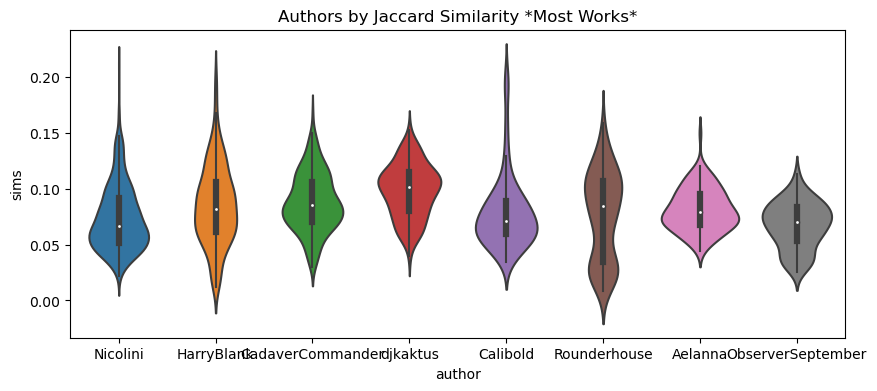

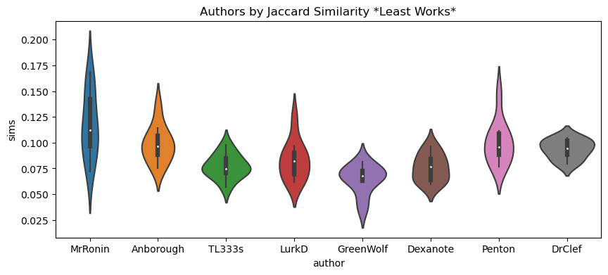

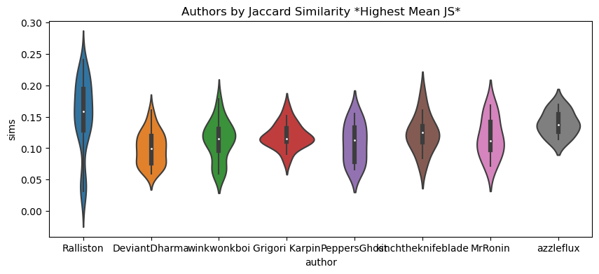

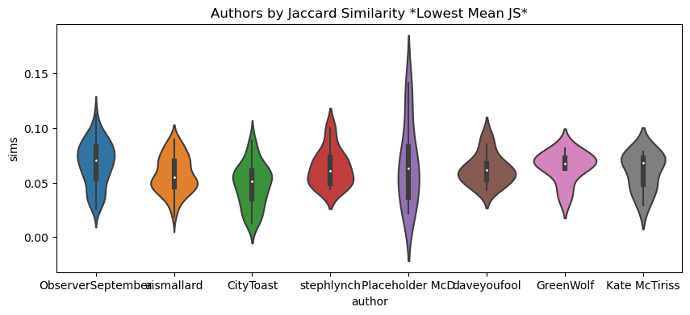

```python
num_cols = ["rating","words length"]

# Too many authors to plot in one plot. Therefor, chunk them out
# to examine some smaller subset based on feature values

# Sorting the authors and subsets
# by works
scp_authors_most_works = list(JSA_df.sort_values("works_count",ascending=False)["author"].values)[:8]
scp_authors_least_works = list(JSA_df.sort_values("works_count",ascending=True)["author"].values)[:8]
# by mean JS
scp_authors_most_JS = list(JSA_df.sort_values("mean_jaccard_sim",ascending=False)["author"].values)[:8]
scp_authors_least_JS = list(JSA_df.sort_values("mean_jaccard_sim",ascending=True)["author"].values)[:8]

author_chunks = [scp_authors_most_works,scp_authors_least_works,scp_authors_most_JS,scp_authors_least_JS]

subset_names = ["Most Works","Least Works","Highest Mean JS","Lowest Mean JS"]

for i,x in enumerate(author_chunks):
    plot_df = JS_author_df[JS_author_df["author"].isin(x)]

    plt.figure(figsize=(10,4))
    ax = sns.violinplot(x=plot_df["author"],y=plot_df["sims"])
    ax.set_title(f"Authors by Jaccard Similarity *{subset_names[i]}*")
```

The distribution of similarity scores within an author's own works shows different behaviors. Some are tight around the middle of similarity scores and don’t stray too far up and down. This may be authors writing individual articles outside of a series but not getting radically experimental. Many have short long tails at higher similarity scores. This may potentially indicate creating short series or otherwise a few related articles. Tails to the bottom likely indicate the author going highly experimental with the format or at least far outside their standard style. Ralliston, the author with the highest mean similarity score, is quite elongated with many articles highly similar to each other. However, it still has a tail at the very low end, potentially indicating an attempt to stray from their standard format. Roundhouse looks bimodal, which might be an indication of experiment after writing in a more standard format or visa-versa.

# Social Network Analysis

```python
%%time
scp_sna = nx.Graph()

scp_ref = scp_df.loc[scp_df["SCPs referenced length"] > 0]

for i, row in scp_ref.iterrows():
    x = row["item_#"]
    for y in row["SCPs referenced"]:
        scp_sna.add_edge(x,y)
```

```
CPU times: total: 484 ms
Wall time: 824 ms
```

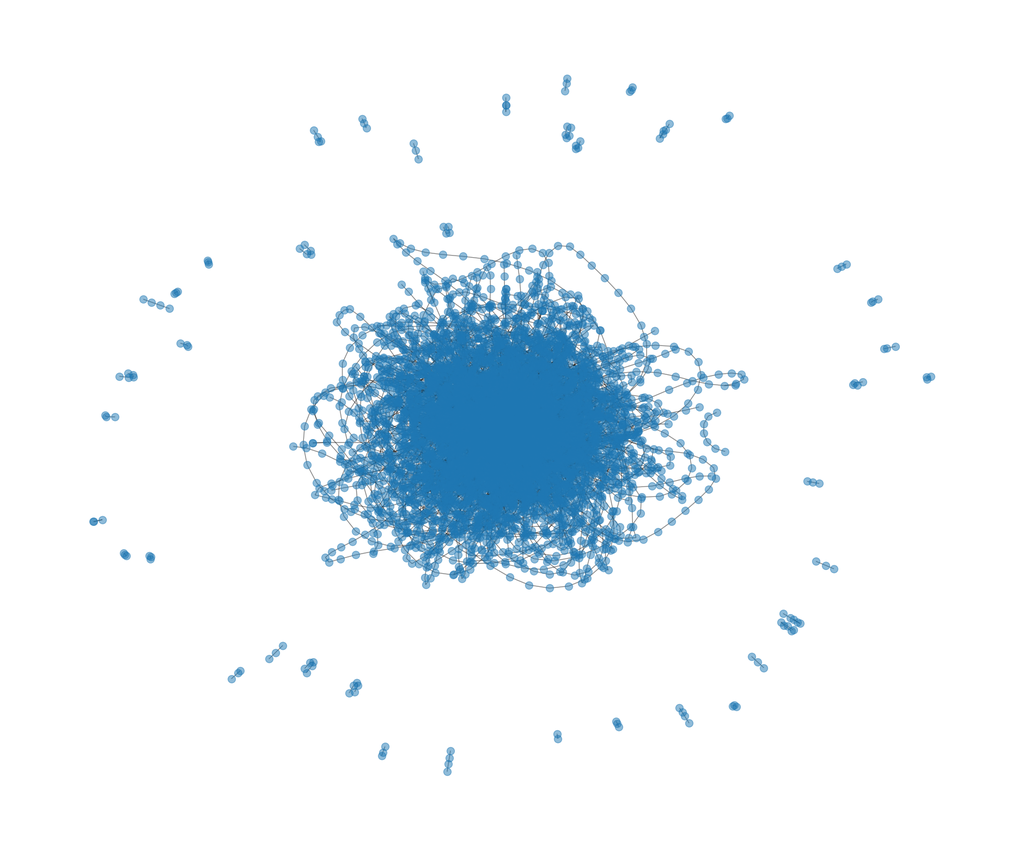

```python
fig,ax = plt.subplots(figsize=(24,20))
nx.draw(scp_sna, with_labels=False, alpha=0.5, node_size=100, ax=ax)
```

Can see from the initial social network graph that there are many interconnected nodes in the center while there are some SCP nodes on the perimeter connected to themselves but not the greater mass. It’s clear that we’ll have to do some selective parsing of which nodes to display to not only save computation time but also cut through the noise to focus on areas of interest. I'll have to keep the social network analysis to dataframe analysis at this stage.

### Note on anomaly detection from previous runs.

This method identified a few anomalies in the data the first time it was run. Disappointedly, many of the articles with lots of references were simply due to authors page information getting left in the main text. Identified, I parsed those out to remove authors just listing their other articles from subsequent runs.

```python
%%time
sna_df = pd.DataFrame.from_dict(dict(scp_sna.degree), orient='index', columns=["degree"])

scp_closeness_centrality = nx.closeness_centrality(scp_sna)
sna_df["closeness_centrality"] = scp_closeness_centrality.values()

triangles = nx.triangles(scp_sna)
sna_df["triangle density"] = triangles.values()

clustering = nx.clustering(scp_sna)
sna_df["clustering coefficients"] = clustering.values()

display(sna_df.sort_values("degree", ascending=False)[:50])
```

|  | degree | closeness_centrality | triangle density | clustering coefficients |
| --- | --- | --- | --- | --- |
| 682 | 35 | 0.147658 | 8 | 0.013445 |
| 1 | 28 | 0.141195 | 1 | 0.002646 |
| 500 | 24 | 0.135626 | 6 | 0.021739 |
| 5128 | 22 | 0.136999 | 2 | 0.008658 |
| 2000 | 20 | 0.136846 | 0 | 0.000000 |
| 1000 | 19 | 0.138094 | 3 | 0.017544 |
| 76 | 18 | 0.137834 | 2 | 0.013072 |
| 4410 | 15 | 0.142175 | 0 | 0.000000 |
| 73 | 14 | 0.132527 | 2 | 0.021978 |
| 140 | 14 | 0.131894 | 1 | 0.010989 |
| 173 | 14 | 0.139548 | 0 | 0.000000 |
| 963 | 14 | 0.129865 | 2 | 0.021978 |
| 5830 | 13 | 0.127054 | 1 | 0.012821 |
| 8 | 13 | 0.133284 | 2 | 0.025641 |
| 4010 | 13 | 0.147008 | 3 | 0.038462 |
| 6776 | 13 | 0.134968 | 0 | 0.000000 |
| 217 | 13 | 0.129942 | 0 | 0.000000 |
| 6666 | 12 | 0.135617 | 4 | 0.060606 |
| 231 | 12 | 0.140146 | 2 | 0.030303 |
| 158 | 12 | 0.131002 | 1 | 0.015152 |
| 79 | 12 | 0.137898 | 2 | 0.030303 |
| 3999 | 12 | 0.130739 | 0 | 0.000000 |
| 6186 | 12 | 0.117478 | 0 | 0.000000 |
| 343 | 11 | 0.136150 | 0 | 0.000000 |
| 914 | 11 | 0.130351 | 1 | 0.018182 |
| 2486 | 11 | 0.118916 | 0 | 0.000000 |
| 3 | 11 | 0.119668 | 0 | 0.000000 |
| 909 | 10 | 0.116234 | 3 | 0.066667 |
| 423 | 10 | 0.116097 | 2 | 0.044444 |
| 6044 | 10 | 0.133451 | 5 | 0.111111 |
| 239 | 10 | 0.129917 | 0 | 0.000000 |
| 4199 | 9 | 0.115748 | 0 | 0.000000 |
| 882 | 9 | 0.129609 | 0 | 0.000000 |
| 148 | 9 | 0.123026 | 0 | 0.000000 |
| 55 | 9 | 0.135846 | 0 | 0.000000 |
| 427 | 9 | 0.122593 | 2 | 0.055556 |
| 5016 | 9 | 0.133216 | 0 | 0.000000 |
| 2798 | 9 | 0.132444 | 0 | 0.000000 |
| 610 | 9 | 0.124388 | 0 | 0.000000 |
| 6055 | 9 | 0.119714 | 3 | 0.083333 |
| 6382 | 9 | 0.125493 | 1 | 0.027778 |
| 507 | 9 | 0.125235 | 0 | 0.000000 |
| 2305 | 9 | 0.118883 | 0 | 0.000000 |
| 6330 | 9 | 0.121733 | 6 | 0.166667 |
| 1680 | 8 | 0.109262 | 1 | 0.035714 |
| 4293 | 8 | 0.104219 | 1 | 0.035714 |
| 2400 | 8 | 0.119948 | 1 | 0.035714 |
| 6820 | 8 | 0.136045 | 0 | 0.000000 |
| 999 | 8 | 0.138937 | 4 | 0.142857 |
| 2578 | 8 | 0.115651 | 2 | 0.071429 |

```
CPU times: total: 37.4 s
Wall time: 52.2 s
```

```python
scp_df[scp_df["item_#"].isin(list(sna_df.sort_values("degree", ascending=False)[:10].index.values))]
```

|  | code | title | text | image captions | rating | state | tags | link | item_# | author | ... | westhead-media | wilsons-wildlife | wonderful-world | wooden | xenarthran | xia-dynasty | zyn-kiryu | Object Class | lsh recommendations | mean JS for top recommendations |
| --- | --- | --- | --- | --- | --- | --- | --- | --- | --- | --- | --- | --- | --- | --- | --- | --- | --- | --- | --- | --- | --- |
| 0 | SCP-001 | "Awaiting De-classification [Blocked]" | "GENERAL NOTICE 001-Alpha: In order to prevent... | (Missing_Caption) | 0.0 | blocked | _cc _licensebox hub | https://scp-wiki.wikidot.com/scp-001 | 1 | Staff | ... | 0 | 0 | 0 | 0 | 0 | 0 | 0 | missing | [5536, 6049, 6149, 3184, 3039] | 0.032190 |
| 72 | SCP-073 | ""Cain"" | "Item #: SCP-073 \n Object Class: Euclid \n Sp... | (Missing_Caption) | 1129.0 | active | able alive cain carnivorous engraved euclid hu... | https://scp-wiki.wikidot.com/scp-073 | 73 | <UNKNOWN> | ... | 0 | 0 | 0 | 0 | 0 | 0 | 0 | euclid | [4992, 5729, 223, 377, 5343] | 0.070321 |
| 75 | SCP-076 | ""Able"" | "FROM: Dr. █████ █. █████\nTO: Director Maria ... | (Missing_Caption) | 1472.0 | active | able alive engraved extradimensional hostile h... | https://scp-wiki.wikidot.com/scp-076 | 76 | <UNKNOWN> | ... | 0 | 0 | 0 | 0 | 0 | 0 | 0 | keter | [1990, 136, 2556, 827, 508] | 0.097380 |
| 139 | SCP-140 | "An Incomplete Chronicle" | "Item #: SCP-140 \n Object Class: Keter \n Spe... | "A reproduction of SCP-140" | 1455.0 | active | _cc _licensebox autonomous daevite document hi... | https://scp-wiki.wikidot.com/scp-140 | 140 | Michal Příhoda | ... | 0 | 0 | 0 | 0 | 0 | 0 | 0 | keter | [4960, 1065, 1833, 782, 4820] | 0.077302 |
| 499 | SCP-500 | "Panacea" | "Item #: SCP-500 \n Object Class: Safe \n Spec... | (Missing_Caption) | 1039.0 | active | chemical container medical safe scp | https://scp-wiki.wikidot.com/scp-500 | 500 | <UNKNOWN> | ... | 0 | 0 | 0 | 0 | 0 | 0 | 0 | safe | [1153, 1972, 2774, 1112, 991] | 0.082488 |
| 681 | SCP-682 | "Hard-to-Destroy Reptile" | "Item #: SCP-682 \n Object Class: Keter \n Spe... | "SCP-682 shortly after escaping from containme... | 3134.0 | active | _cc _licensebox adaptive alive audio co-author... | https://scp-wiki.wikidot.com/scp-682 | 682 | Edna Granbo | ... | 0 | 0 | 0 | 0 | 0 | 0 | 0 | keter | [1475, 5550, 5750, 663, 797] | 0.055094 |
| 999 | SCP-1000 | "Bigfoot" | "Item #: SCP-1000 \n Object Class: Keter \n Sp... | "Still from unverified amateur footage" | 1778.0 | active | 1000 _cc _licensebox alive children-of-the-nig... | https://scp-wiki.wikidot.com/scp-1000 | 1000 | Waldo93\nNote: Pixabay moved to its own Pixaba... | ... | 0 | 0 | 0 | 0 | 0 | 0 | 0 | keter | [1540, 4487, 4008, 2893, 1976] | 0.102389 |
| 1999 | SCP-2000 | "Deus Ex Machina" | "Attempting access beyond this point without n... | (Missing_Caption) | 2094.0 | active | 2000 _cc _licensebox doctor-clef doctor-gears ... | https://scp-wiki.wikidot.com/scp-2000 | 2000 | HammerMaiden | ... | 0 | 0 | 0 | 0 | 0 | 0 | 0 | thaumiel | [5795, 900, 2737, 4277, 6198] | 0.105252 |
| 4409 | SCP-4410 | "The Ongoing Development of an Art Form" | "You are attempting to access a Foundation Spe... | (Missing_Caption) | 139.0 | active | 4000 euclid meta narrative online ontokinetic ... | https://scp-wiki.wikidot.com/scp-4410 | 4410 | <UNKNOWN> | ... | 0 | 0 | 0 | 0 | 0 | 0 | 0 | euclid | [2306, 4914, 2682, 4152, 1214] | 0.073357 |
| 5127 | SCP-5128 | "The Source" | "Item #: SCP-5128 \n Object Class: Thaumiel \n... | (Missing_Caption) | 66.0 | active | 5000 _listpages chaos-insurgency concept infoh... | https://scp-wiki.wikidot.com/scp-5128 | 5128 | <UNKNOWN> | ... | 0 | 0 | 0 | 0 | 0 | 0 | 0 | keter | [4962, 301, 6030, 884, 4989] | 0.028159 |

10 rows × 541 columns

No surprise that some of the most connected articles are also the most popular articles. 682 at the top is the hard to destroy reptile. SCP-682 is basically invincible as it will always adapt to whatever damage. As such, writers tend to put it up against other powerful SCPs and it functions as the immovable object in these unstoppable force vs immovable object scenarios. 500 is a panacea that cures all disease. Similar placed in testing logs against SCPs that are infectious. A lot are based on testing logs.

# Other Methods Attempeted

I will just note that I did quite a bit of work on clustering methods using TD-IDF and dimensionality reduction. However, this did not yield meaningful results at this stage as the clustering methods on text data did not meaningfully separate the texts. What little could be drawn from it was better done with the similarity searching. I suspect that incorporating neural network embeddings and deep learning though that is beyond the scope of this class to incorporate. The code is not currently useful, in a separate notebook, and cluttered. Therefore, I’ll leave it out to not fill the report with messy code.

I also did some supervised learning and simple text generation. However, that is not related to the topics of this class so also parsed out.

# Conclusions and Improvements Future Work

- After trying various methods of data analysis on this set, similarity searching has proven to be most effective. This is not too surprising as it is a method used in class that was designed for text data analysis. Similarity search methods have shown to be quite effective for this task. It would be good to attempt similarity search using more advanced metrics. Though more advanced similarity search methods I found were too slow to go through the database in a reasonable amount of time. Would have to be particularly strict about subsetting articles combinations to investigate.
- Social network analysis was an outside the box experimentation of it’s normal use. It definitely produced some useful results but it’s not as principled of an application and would need to experiment more.
- TD-IDF was used for both clustering and dimensionality reduction, similar to what was done in class. It would be good to try with more advanced trained neural network embeddings. Though training embeddings takes some time and outside the techniques of this class. An autoencoder may be promising, as it is semi-supervised (requiring no labels), and would be a combination of both custom embedding creation and custom dimensionality reduction in one model.
- The dataset was a bit more limited and inconsistent than I would have liked it to be. A lot of time was needed for specialized cleaning and feature extraction from inconsistent formats and a lot of data was missing. Building a better web scraper to update and collect missing information would be useful for improvements. However, it would be good to deploy these methods on a larger dataset of short story writing from another source.
- I’d be curious to attempt market basket style analysis using a word bag from documents as kind of a basket. Then it should be possible to evaluate a word appearing if another word appeared and similar evaluations. I did not attempt this acknowledging that this set is too small with potentially very long texts for this to feasibly work. It’s an unusual idea but on a larger set of documents with less text per document something like this may work.